# Clustering: A pipeline to analyse time-course gene expression data

# Clustering of time-course data

The very large number of genes found differentially expressed impair any interpretation one would attempt: with 70% of the genome found differentially expressed, all pathways are affected by the treatment. Hence the next step of the workflow to cluster gene expression according to their dynamical response to the treatment. Before clustering the genes, we first reduce the set of genes of interest to genes that are (1) significantly found differentially expressed; (2) “highly” differentially expressed. To do this, we first aggregate all p-values obtained during the time-course differential expresison step in a single p-value using Fisher’s method (Fisher 1925). Then we select all the genes which have a Fisher adjusted p-value below 0.05 and a log fold change of at least two between at least one condition and one time-point. Reducing the set of genes on which to perform the clustering allows to estimate the centroids with more stability.

```r
# Then rank by fisher's p-value and take max the number of genes of interest
# Filter out q-values for the pvalues table
fishers_pval = moanin::pvalues_fisher_method(pvalues)
fishers_qval = stats::p.adjust(fishers_pval)

genes_to_keep = row.names(
    lfc_max[(rowSums(lfc_max > 2) > 0) & (fishers_qval < 0.05), ])
y = as.matrix(data[genes_to_keep, ])
```

After filtering, we are left with 5125 genes. We can then apply a clustering. As observed by looking at genes found differentially expressed, many genes share a similar gene expression pattern, but on different scale. We thus propose the following adaptation of k-means:

- **Splines estimation**: for each gene, fit the splines function with the basis of your choice.
- **Rescaling splines**: for each gene, rescale the estimated splines function such that the values are bounded between 0 and 1.
- **K-means**: apply k-means on the rescaled fitted splines to estimate the centroids.
- **Assign scores and labels to all genes**: then assign a score and a label to all gene based on a goodness-of-fit measure on the raw data. By default, the `splines_kmeans_score_and_label` function only labels the best 50% of genes.

The first three steps are performed jointly by the `splines_kmeans` function.

```r
# First fit the kmeans clusters
kmeans_clusters = moanin::splines_kmeans(
    y, splines_model, n_clusters=8,
    random_seed=42,
    n_init=20)
```

We then use the `plot_centroids` function to visualize the centroids obtained with the splines k-means model.

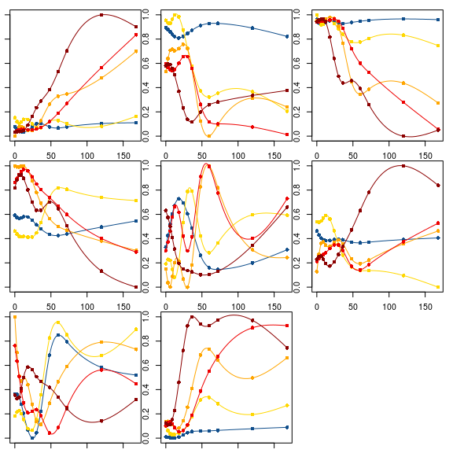

```r
moanin::plot_centroids(kmeans_clusters$centroids, splines_model,
               colors=ann_colors$Group,
               smooth=TRUE)
```

The scoring and labeling can be done via the `splines_kmeans_score_and_label` function.

```r
# Then assign scores and labels to all the data, using a goodness-of-fit
# scoring function.
scores_and_labels = moanin::splines_kmeans_score_and_label(
    data, kmeans_clusters)
labels = scores_and_labels$labels

# Let's keep only the list of genes that have a label.
labels = unlist(labels[!is.na(labels)])
```

Before performing the next steps, let us investigate in more detail the differences between the labels provided by the splines k-means model and the scoring and labelinig step.

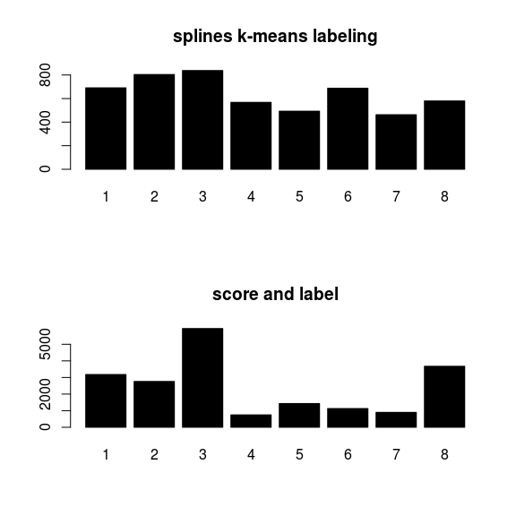

The scoring and label step allows to label genes that were removed during the filtering step, yet are good matches to the centroids found during the clustering.

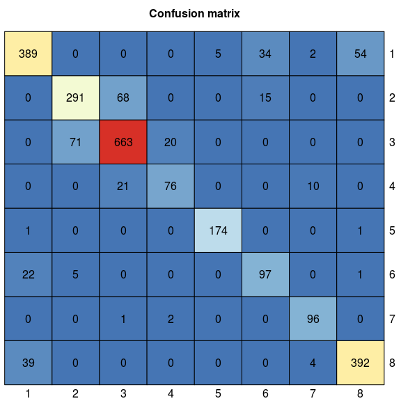

## Looking at specific clusters in details.

Now, let us look more in detail some specific clusters. Cluster 8 seems particularly interesting: it captures genes with strong differences between the differant influenza treatments and the control, while the control remains relatively flat.

Heatmaps are useful to investigate the range of expression patterns for specific genes. Here, we are going to plot heatmaps of the normalized gene expression patterns and the rescaled gene expression patterns side by side.

First, select the genes of interest.

```r
cluster_to_plot = 8
genes_to_plot =  names(labels[labels == cluster_to_plot])
```

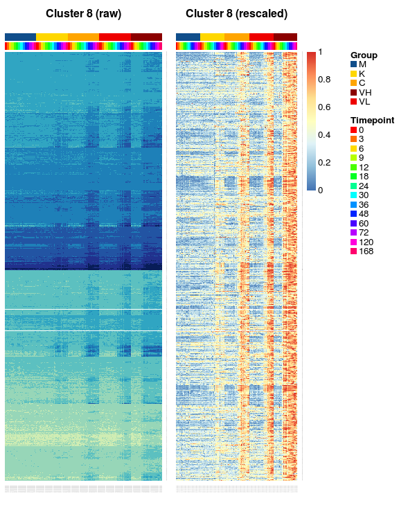

```r
layout(matrix(c(1,2),nrow=1), widths=c(1.5, 2))

data_to_plot = data[genes_to_plot, ]
submeta = meta
ord = order(
  submeta$Group,
  submeta$Timepoint,
  submeta$Replicate)
submeta$Timepoint = as.factor(submeta$Timepoint)

data_to_plot = data_to_plot[, ord]
submeta = submeta[ord, ]

res = NMF::aheatmap(
    data_to_plot,
    Colv=NA,
    color="YlGnBu",
    annCol=submeta[,
                c("Group", "Timepoint")],
    annLegend=FALSE,
    annColors=ann_colors,
    main=paste("Cluster", cluster_to_plot, "(raw)"),
    treeheight=0, legend=FALSE)

# Now use the results of the previous call to aheatmap to reorder the genes.
NMF::aheatmap(
    moanin:::rescale_values(data_to_plot)[res$rowInd,],
    Colv=NA,
    Rowv=NA,
    annCol=submeta[,
                c("Group", "Timepoint")],
    annLegend=TRUE,
    annColors=ann_colors,
    main=paste("Cluster", cluster_to_plot, "(rescaled)"),
    treeheight=0)
```

Those two heatmaps demonstrate that the clustering method successfully cluster genes that are on different scales, and yet share the same dynamical response to the treatments.

## How to choose the number of clusters.

A common question that arises when performing clustering is how to choose the number of clusters. A choice for the number of clusters K depends on the goal. In this particular case, the end goal is not the clustering, but to facilitate interpretation of the differential expression analysis step. As a result, the number of clusters should not exceed the number of gene sets the user wants to interpret. This allows to set a maximum number of clusters. Let us assume here that this number is 20 clusters.

Once the maximum number of clusters is set, several strategies allow to identify the number of clusters:

- **Elbow method**. First introduced in 1953 by Thorndike (Thorndike 1953), the elbow methods looks at the total with cluster sum of squares as a function of the number of clusters (WCSS). When adding clusters doesn’t decrease the WCSS by a sufficient amount, one can consider stopping. This method thus provides visual aid to the user to choose the number of clusters, but often the “elbow” is hard to see on real data, where the number of clusters is not clearly defined.
- **Silhouette method**. Similarly to the Elbow method, the Silhouette method refers to a method of validation of consistency within clusters, and provides visual aid to choose the number of clusters.
- **Stability methods** Stability methods are more computationally intensive than any other method, as they rely on assessing the stability of the clustering for every $k$ to a small randomization of the data. The user is then invited to choose the number of cluster based on a number of similarity measures.

First, let us run the clustering for all possible clusters of interest. We will, for each clustering experiment, conserve (1) with within cluster sum of squares; (2) the labels assigned to all genes.

```r
all_possible_n_clusters = c(5, 9, 11, 15)
all_clustering = list()
wss_values = list()

i = 1
for(n_cluster in all_possible_n_clusters){
    clustering_results = moanin::splines_kmeans(
    y, splines_model,
    n_clusters=n_cluster, random_seed=42,
    n_init=10)
    wss_values[i] = sum(clustering_results$WCSS_per_cluster)
    all_clustering[[i]] = clustering_results$clusters
    i = i + 1
}
```

### Elbow method

The Elbow method to choose the number of clusters relies on visualization aid to choose the number of cluster. The method relies on plotting the within cluster sum of squares as a function of the number of clusters. At some point, the WCSS will stop dropping, giving an angle in the graph. The number of cluster is chosen at this “Elbow point.”

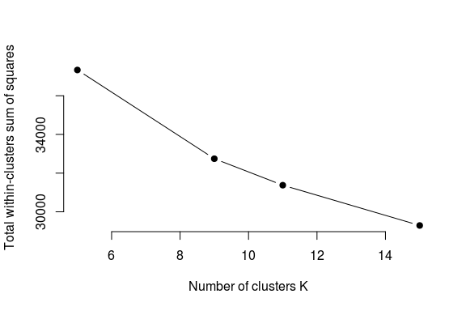

```r
plot(all_possible_n_clusters, wss_values,
     type="b", pch=19, frame=FALSE,
     xlab="Number of clusters K",
     ylab="Total within-clusters sum of squares")
```

### Average silhouette method

The silhouette value is a measure of how similar a data point is to its own cluster (cohesion) compared to other clusters (separation).

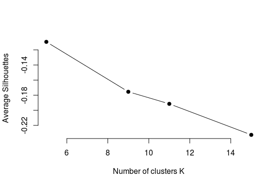

```r
# function to compute average silhouette for k clusters
average_silhouette = function(labels, y) {
    silhouette_results = cluster::silhouette(unlist(labels[1]), dist(y))
    return(mean(silhouette_results[, 3]))
}

# extract the average silhouette
average_silhouette_values = list()
i = 1
for(i in 1:length(all_clustering)){
    labels = all_clustering[i]
    average_silhouette_values[i] = average_silhouette(labels, y)
    i = i + 1
}

plot(all_possible_n_clusters, average_silhouette_values,
     type="b", pch=19, frame=FALSE,
     xlab="Number of clusters K",
     ylab="Average Silhouettes")
```

### Looking at the stability of the clustering

On real data, the number of clusters is not only unknown but also ambiguous: it will depend on the desired clustering resolution of the user. Yet, in the case of biological data, stability and reproducibility of the results is necessary to ensure that the biological interpretation of the results hold when the data or the model is exposed to reasonable perturbations.

Methods that rely on the stability of the clustering results to choose $k$ thus ensure that the biological interpretation of the clusters hold with perturbtation to the data. In addition, simulation where the data is generated with a well defined $k$ show that the clustering is more stable for the correct of number of the clusters.

Most methods method to find the number of clusters with stability measures only provide visual aids to guide the user. The first element often visualized is the consensus matrix: the consensus matrix is an $n \times n$ matrix that stores the proportion of clustering in which two items are clustered together. A perfect consensus matrix ordered such as each elements that belong to the same cluster are adjacent to one another which show blocks along the diagonal close to 1.

To perform such analysis, the first step is run the clustering several times on a resampled dataset–either using bootstrap or subsampling.

Using the bootstrapping strategy:

```r
n_genes = dim(y)[1]
indices = sample(1:dim(y)[1], n_genes, replace=TRUE)

bootstrapped_y = y[indices, ]
```

```r
subsample_proportion = 1
indices = sample(1:dim(y)[1], n_genes * subsample_proportion, replace=FALSE)
subsampled_y = y[indices, ]
```

Here we plot to stability matrix of the top 1000 genes for $k=5$ and $k=20$.

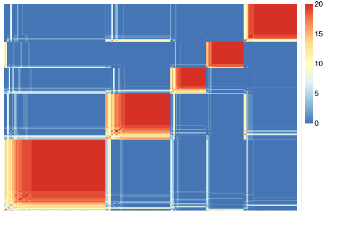

```r
library(NMF)
stability_5 = read.table("results/stability_5.tsv", sep="\t")
consensus_matrix_stability_5 = moanin::consensus_matrix(stability_5,
                            scale=FALSE)
NMF::aheatmap(consensus_matrix_stability_5[1:1000, 1:1000], Rowv=FALSE,
          Colv=FALSE,
          treeheight=0)
```

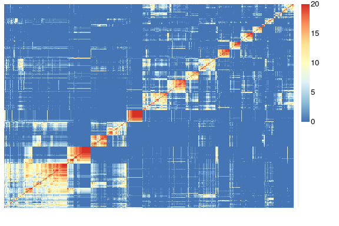

```r
stability_20 = read.table("results/stability_20.tsv", sep="\t")
consensus_matrix_stability_20 = moanin::consensus_matrix(stability_20,
                             scale=FALSE)
NMF::aheatmap(consensus_matrix_stability_20[1:1000, 1:1000], Rowv=FALSE,
          Colv=FALSE,
          treeheight=0)
```

#### The model explorer strategy

The model explorer algorithm (Ben-Hur, Elisseeff, and Guyon 2001) proposes to estimate the number of clusters exploiting the observation that if the number of clusters is correct, the clustering results are stable to bootstrapping. The distribution of similaries between bootstrapped results for each $k$ can thus be compared for different values of $k$ and guide the user in the choice of number of clusters.

The model explorer strategy works as follows. First, choose a similarity measure between two partitions or clusters $S(C_1, C_2)$. Examples are the normalized mutual information or Fowlkes-Mallows. Then perform $n$ bootstrap experiments to estimate the cluster centroids, followed by a step of assigning a label to all data points. Finally, compute the pairwise similarity measure between all bootstrapped partition, and plot the cumulative density of the obtained scores.

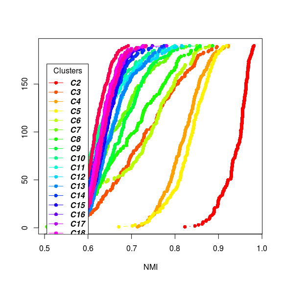

```r
moanin::plot_model_explorer(all_labels)
```

From this plot, we can deduce that $k=5$ is more stable than $k=3$ and $k=4$, but not as stable as $k=2$. The model explorer strategy, in addition to visualizing the diversity of the centroids, can thus help assessing an adequate number of clusters.

Now, replot the same model explorer, but only for the clustering experiments $k=6$, $k=7$, $k=8$, $k=9$ and $k=10$ so that we can see more clearly the stability measures in that range.

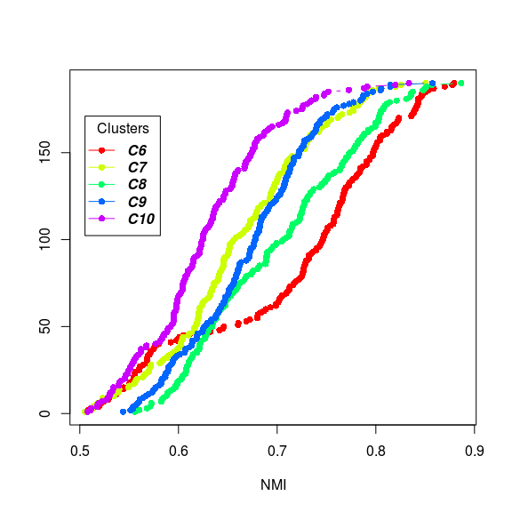

```r
clusters = c("C6", "C7", "C8", "C9", "C10")
selected_labels = all_labels[clusters]
moanin::plot_model_explorer(selected_labels)
```

#### Consensus clustering as a way to find $k$

The consensus clustering (Monti et al. 2003) relies on a similar idea but instead of looking at the cumulative density of similarity measures of bootstrapped clustering, the authors suggests plotting the cumulative density of elements of the consensus matrix.

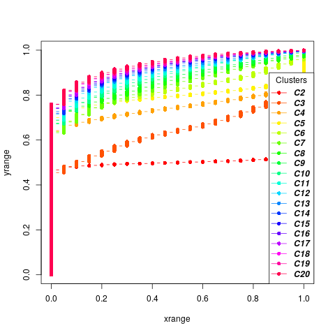

```r
moanin::plot_cdf_consensus(all_labels)
```

The stability of the clustering based on the consensus matrix can then be measured via a single number by looking at the area under the curve: the more stable the clustering, the closer to 0 or 1 will be the entries of consensus matrix. The consensus clustering strategy thus suggest at looking at either the AUC as a function of the number of the clusters or the “improvement” in the AUC as a function of the number of cluster.

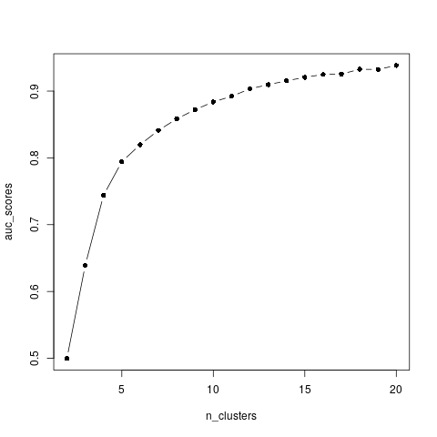

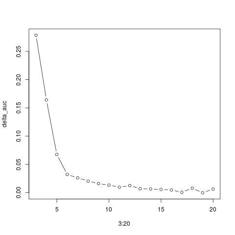

The consensus clustering method suggest that the most stable is $k=2$, which separates over-expressed genes from under-expressed genes. While it is indeed a very stable clustering, it does not capture the range of gene expression patterns present in the data. This shows the limitation of such method on real data, where the number of clusters is not clearly defined.

# References

Ben-Hur, Asa, André Elisseeff, and Isabelle Guyon. 2001. “A Stability Based Method for Discovering Structure in Clustered Data.” *Pacific Symposium on Biocomputing. Pacific Symposium on Biocomputing*, 6–17.

Fisher, R.A. 1925. *Statistical Methods for Research Workers*. Edinburgh Oliver & Boyd.

Monti, Stefano, Pablo Tamayo, Jill Mesirov, and Todd Golub. 2003. “Consensus Clustering: A Resampling-Based Method for Class Discovery and Visualization of Gene Expression Microarray Data.” *Machine Learning* 52 (1): 91–118. https://doi.org/10.1023/A:1023949509487.

Thorndike, Robert L. 1953. “Who Belongs in the Family?” *Psychometrika* 18 (4): 267–76. https://doi.org/10.1007/BF02289263.